# 진리장학금 1차보고서

by Hyeonwoo Yoo

# Objective

- Novely Detection / Anomaly Detection on [NASA Bearing Dataset](http://data-acoustics.com/measurements/bearing-faults/bearing-4/)
- Approach with two reconstruction methods
  - Principal Component Analysis Reconsturciton
  - Variatioanl Autoencoder Reconstruction

# About Novelty Detection, Anomaly Detection

## Anomaly detection

- **Identification of rare items, events or observations which raise suspicions by differing significantly from the majority of the data**
- Three methods for anomaly detectoin
  - **Unsupervised** : Unlabeled test data set under the assumption that the majority of the instances in the data set are normal
  - **Supervised** : Labeled, imbalanced data set (normal/abnormal)
  - **Semi-Supervised** : Model representing normal behavior from a given normal training data set.
- e.g.) Bank fraud, Structual defect, System health monitoring, Intrusion detection, Fault detection, Ecosystem disturbances
- Source : [Wikipedia](https://goo.gl/YOdhxK)
- By [scikit-learn](https://goo.gl/csTPJr) : *'Training data contains outliers'*

## Novelty Detection

- **Mechanism by which an intelligent organism is able to identify an incoming sensory pattern as being hitherto unknown**
- The principle is long known in **neurophysiology(신경생리학)**
- 'Early neural modeling attempts were by Yehuda Salu(1988)'
- Source : [Wikipedia](https://goo.gl/6mntxw)
- By [scikit-learn](https://goo.gl/csTPJr) : *'Training data is not polluted by outliers'*

# Evaluation Metrics for Anomaly & Novelty Detection

## Metrics for Anomaly & Novelty Detection

[figure not shown]

## ROC (Receiver Operating Characteristics)

- **False positive rate(FPR)** versus the **true positive rate(TPR)(=Recall)** for a number of different candidate threshold values between 0.0 and 1.0
- In other words, it plots the false alarm rate versus the hit rate

## AUC (Area Under the Curve)

- Literally area under the ROC curve
- AUC ranges in value from 0 to 1. A model whose predictions are 100% wrong has an AUC of 0.0; one whose predictions are 100% correct has an AUC of 1.0.

## PRC (Precision-Recall Curve)

- **Precision** versus the **Recall**
- To know how good a model is at predicting the positive class

## Better metric for class-imbalanced data

- Precision captures false positive more sensitively than FPR, **thus PRC is more appropriate than ROC when it comes to class-imbalanced problem**

> e.g.)  
> 1 million samples, 100 positive and others are all negative  
> case1) 100 predicted positive, 90 true positive  
> case2) 2000 predicted positive, 90 true positive  
> case1) 0.9 TPR, 0.00001 FPR  
> case2) 0.9 TPR, 0.00191 FPR  
> FPR difference = 0.00190  
> case1) 0.9 Recall, 0.9 Precision  
> case2) 0.9 Recall, 0.045 Precision  
> Precision difference = 0.855  
> Upon same false positive difference, precision shows bigger difference than FPR. In other words, precision is more sensitive to false positives

# About Dataset

- NASA bearing dataset
- Made available by NASA
- Goals
  - to detect gear bearing degradation on an engine
  - to give a warning that allows for predictive measures to be taken in order to avoid a gear failure

# Exploratory Data Analysis

```python
import os
import pandas as pd
import numpy as np
import matplotlib.pyplot as plt
import seaborn as sns

from sklearn.preprocessing import MinMaxScaler
from sklearn.decomposition import PCA

import torch
import torch.nn as nn
import torch.nn.functional as F
from torch.utils.data import DataLoader
import tqdm
import copy
```

```python
import ipywidgets as widgets
from ipywidgets import interact, interact_manual

sns.set(style='whitegrid', palette='muted')

%matplotlib inline
%load_ext autoreload
%autoreload 2
```

```python
data_dir = os.path.abspath(os.path.join(os.getcwd(), 'data', '2nd_test'))
df = pd.DataFrame()

for filename in os.listdir(data_dir) :
    try :
        path = os.path.abspath(os.path.join(os.getcwd(), 'data', '2nd_test', filename))
        dataset = pd.read_csv(path, sep='\t')

        dataset_mean_abs = np.array(dataset.abs().mean())
        dataset_mean_abs = pd.DataFrame(dataset_mean_abs.reshape(1,4))
        dataset_mean_abs.index = [filename]

        df = df.append(dataset_mean_abs)
    except Exception as e:
        print(e)

df.columns = ['Bearing 1', 'Bearing 2', 'Bearing 3', 'Bearing 4']
```

```
Error tokenizing data. C error: Expected 2 fields in line 4, saw 5
```

```python
df.index = pd.to_datetime(df.index, format='%Y.%m.%d.%H.%M.%S')
df = df.sort_index()
```

```python
@interact
def show(x=df.shape[0]) :
    return df.iloc[x:x+10]
```

```python
@interact
def plot(x=df.shape[0]) :
    plt.figure(figsize=(20,5))
    plt.plot(df['Bearing 1'].iloc[x:x+100])
    plt.plot(df['Bearing 2'].iloc[x:x+100])
    plt.plot(df['Bearing 3'].iloc[x:x+100])
    plt.plot(df['Bearing 4'].iloc[x:x+100])
    plt.legend()
    plt.xlabel('Time')
    plt.ylabel('Value')
    plt.title('Gear Virbation')
    plt.show()
```

```python
def show_all_period_plot(df) :
    plt.figure(figsize=(20, 5))
    plt.plot(df['Bearing 1'], label='Bearing 1')
    plt.plot(df['Bearing 2'], label='Bearing 2')
    plt.plot(df['Bearing 3'], label='Bearing 3')
    plt.plot(df['Bearing 4'], label='Bearing 3')
    plt.legend()
    plt.xlabel('Time')
    plt.ylabel('Value')
    plt.title('Gear Virbation')
    plt.show()
```

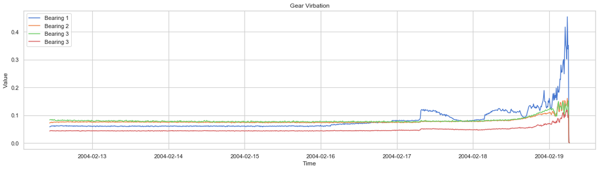

```python
show_all_period_plot(df)
```

```python
x_train = df[:'2004-02-16 22:02:39']
x_valid = df['2004-02-16 22:02:39':]
```

```python
print(x_train.shape)
print(x_valid.shape)
```

```
(646, 4)
(339, 4)
```

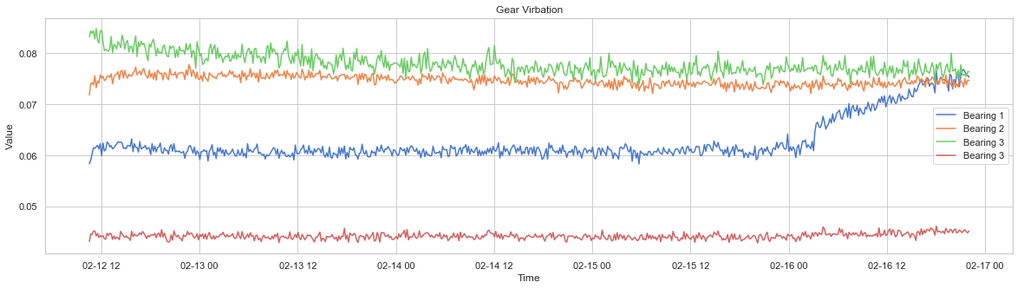

```python
show_all_period_plot(x_train)
```

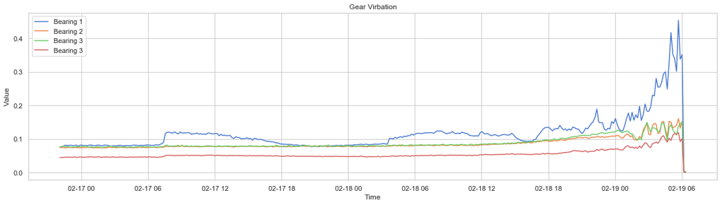

```python
show_all_period_plot(x_valid)
```

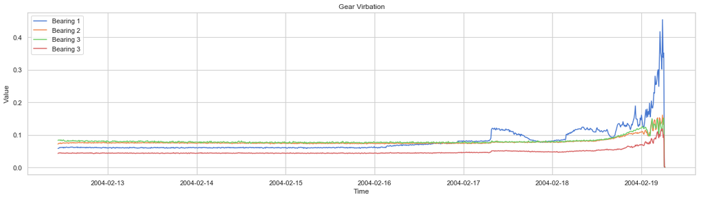

```python
show_all_period_plot(pd.concat([x_train, x_valid]))
```

```python
minmaxscaler = MinMaxScaler()

x_train = pd.DataFrame(minmaxscaler.fit_transform(x_train), columns=x_train.columns, index=x_train.index)
x_valid = pd.DataFrame(minmaxscaler.transform(x_valid), columns=x_valid.columns, index=x_valid.index)
```

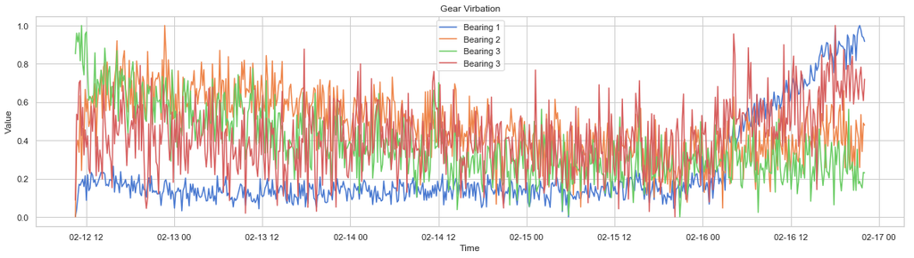

```python
show_all_period_plot(x_train)
```

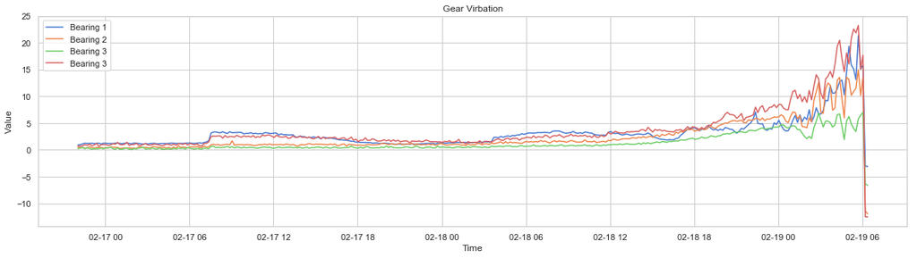

```python
show_all_period_plot(x_valid)
```

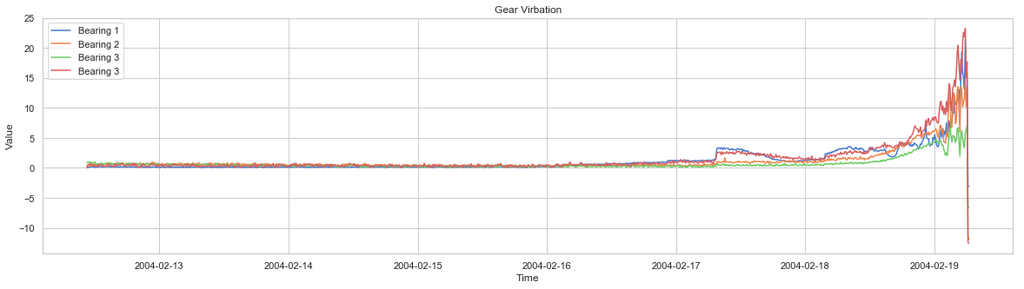

```python
show_all_period_plot(pd.concat([x_train, x_valid]))
```

# Novelty Detection using PCA Reconstruction

```python
pca = PCA(n_components=4)
pca.fit(x_train)
```

```
PCA(copy=True, iterated_power='auto', n_components=4, random_state=None,
  svd_solver='auto', tol=0.0, whiten=False)
```

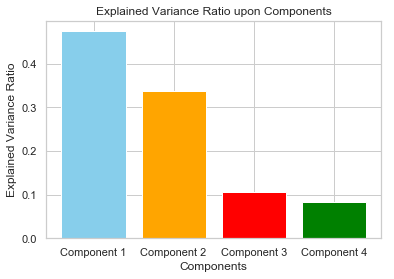

```python
plt.bar(['Component 1', 'Component 2', 'Component 3', 'Component 4'], pca.explained_variance_ratio_, color=['skyblue', 'orange', 'red', 'green'])
plt.xlabel('Components')
plt.ylabel('Explained Variance Ratio')
plt.title('Explained Variance Ratio upon Components')
plt.show()
```

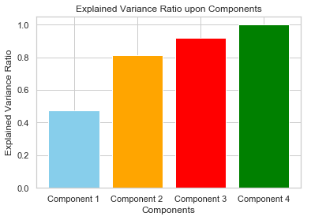

```
[0.4746206  0.81127943 0.91640243 1.        ]
```

```python
plt.bar(['Component 1', 'Component 2', 'Component 3', 'Component 4'], np.cumsum(pca.explained_variance_ratio_), color=['skyblue', 'orange', 'red', 'green'])
plt.xlabel('Components')
plt.ylabel('Explained Variance Ratio')
plt.title('Explained Variance Ratio upon Components')
plt.show()
print(np.cumsum(pca.explained_variance_ratio_))
```

## Number of Components = 2

```python
pca = PCA(n_components=2, svd_solver='full')

x_train_pca = pd.DataFrame(pca.fit_transform(x_train), index=x_train.index)
x_valid_pca = pd.DataFrame(pca.transform(x_valid), index=x_valid.index)
```

```python
print(x_train_pca.shape)
print(x_valid_pca.shape)
```

```
(646, 2)
(339, 2)
```

```python
display(x_train_pca.head())
display(x_valid_pca.head())
```

|  | 0 | 1 |
| --- | --- | --- |
| 2004-02-12 10:32:39 | -0.379091 | -0.165629 |
| 2004-02-12 10:42:39 | -0.257896 | 0.322483 |
| 2004-02-12 10:52:39 | -0.210759 | 0.313994 |
| 2004-02-12 11:02:39 | -0.070890 | 0.397639 |
| 2004-02-12 11:12:39 | -0.088929 | 0.489085 |

|  | 0 | 1 |
| --- | --- | --- |
| 2004-02-16 22:02:39 | 0.733423 | 0.142553 |
| 2004-02-16 22:12:39 | 0.743653 | 0.185636 |
| 2004-02-16 22:22:39 | 0.849600 | 0.289164 |
| 2004-02-16 22:32:39 | 1.156566 | 0.190001 |
| 2004-02-16 22:42:39 | 0.984879 | 0.272958 |

```python
x_train_pca_recon = pd.DataFrame(pca.inverse_transform(x_train_pca), index=x_train.index, columns=df.columns)
x_valid_pca_recon = pd.DataFrame(pca.inverse_transform(x_valid_pca), index=x_valid.index, columns=df.columns)
```

```python
print(x_train_pca_recon.shape)
print(x_valid_pca_recon.shape)
```

```
(646, 4)
(339, 4)
```

```python
x_train_mse = (x_train_pca_recon - x_train)
x_valid_mse = (x_valid_pca_recon - x_valid)
```

```python
x_train_mse['Reconstruction Error'] = x_train_mse.mean(axis=1).apply(lambda x : x*x)
x_valid_mse['Reconstruction Error'] = x_valid_mse.mean(axis=1).apply(lambda x : x*x)
```

```python
display(x_train.head(),)
display(x_train_pca_recon.head())
display(x_train_mse.head())
```

|  | Bearing 1 | Bearing 2 | Bearing 3 | Bearing 4 |
| --- | --- | --- | --- | --- |
| 2004-02-12 10:32:39 | 0.002152 | 0.000000 | 0.851843 | 0.088117 |
| 2004-02-12 10:42:39 | 0.037843 | 0.364172 | 0.959840 | 0.536515 |
| 2004-02-12 10:52:39 | 0.104727 | 0.401176 | 0.913750 | 0.506727 |
| 2004-02-12 11:02:39 | 0.170414 | 0.337099 | 0.961833 | 0.700840 |
| 2004-02-12 11:12:39 | 0.165312 | 0.632695 | 0.815186 | 0.712082 |

|  | Bearing 1 | Bearing 2 | Bearing 3 | Bearing 4 |
| --- | --- | --- | --- | --- |
| 2004-02-12 10:32:39 | -0.100647 | 0.456851 | 0.382074 | 0.180047 |
| 2004-02-12 10:42:39 | 0.078229 | 0.732311 | 0.661472 | 0.438898 |
| 2004-02-12 10:52:39 | 0.115342 | 0.717134 | 0.642026 | 0.456452 |
| 2004-02-12 11:02:39 | 0.243277 | 0.739220 | 0.654628 | 0.554155 |
| 2004-02-12 11:12:39 | 0.243509 | 0.799419 | 0.719040 | 0.584400 |

|  | Bearing 1 | Bearing 2 | Bearing 3 | Bearing 4 | Reconstruction Error |
| --- | --- | --- | --- | --- | --- |
| 2004-02-12 10:32:39 | -0.102800 | 0.456851 | -0.469768 | 0.091930 | 0.000035 |
| 2004-02-12 10:42:39 | 0.040386 | 0.368138 | -0.298368 | -0.097617 | 0.000010 |
| 2004-02-12 10:52:39 | 0.010614 | 0.315958 | -0.271724 | -0.050274 | 0.000001 |
| 2004-02-12 11:02:39 | 0.072863 | 0.402122 | -0.307205 | -0.146686 | 0.000028 |
| 2004-02-12 11:12:39 | 0.078197 | 0.166724 | -0.096147 | -0.127681 | 0.000028 |

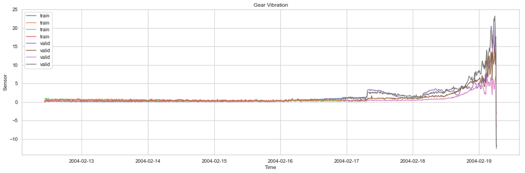

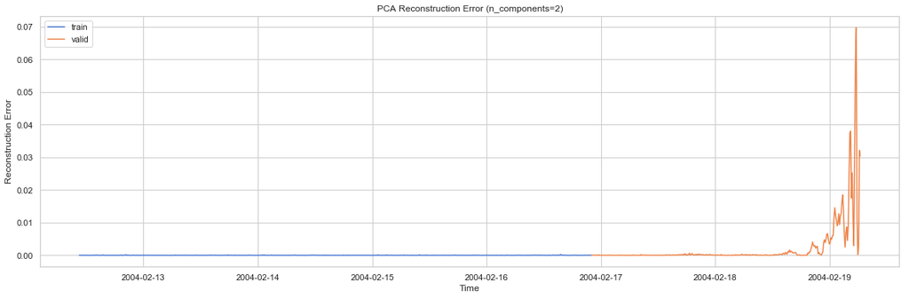

```python
plt.figure(figsize=(20,6))
plt.plot(x_train, label='train')
plt.plot(x_valid, label='valid')
plt.legend()
plt.xlabel('Time')
plt.ylabel('Sensor')
plt.title('Gear Vibration')
plt.show()

plt.figure(figsize=(20, 6))
plt.plot(x_train_mse['Reconstruction Error'], label='train')
plt.plot(x_valid_mse['Reconstruction Error'], label='valid')
plt.legend()
plt.xlabel('Time')
plt.ylabel('Reconstruction Error')
plt.title('PCA Reconstruction Error (n_components=2)')
plt.show()
```

## Number of Components = 3

```python
pca = PCA(n_components=3, svd_solver='full')

x_train_pca = pd.DataFrame(pca.fit_transform(x_train), index=x_train.index)
x_valid_pca = pd.DataFrame(pca.transform(x_valid), index=x_valid.index)
```

```python
print(x_train_pca.shape)
print(x_valid_pca.shape)
```

```
(646, 3)
(339, 3)
```

```python
display(x_train_pca.head())
display(x_valid_pca.head())
```

|  | 0 | 1 | 2 |
| --- | --- | --- | --- |
| 2004-02-12 10:32:39 | -0.379091 | -0.165629 | 0.222976 |
| 2004-02-12 10:42:39 | -0.257896 | 0.322483 | -0.044927 |
| 2004-02-12 10:52:39 | -0.210759 | 0.313994 | 0.005273 |
| 2004-02-12 11:02:39 | -0.070890 | 0.397639 | -0.101475 |
| 2004-02-12 11:12:39 | -0.088929 | 0.489085 | -0.129541 |

|  | 0 | 1 | 2 |
| --- | --- | --- | --- |
| 2004-02-16 22:02:39 | 0.733423 | 0.142553 | 0.100286 |
| 2004-02-16 22:12:39 | 0.743653 | 0.185636 | 0.176447 |
| 2004-02-16 22:22:39 | 0.849600 | 0.289164 | 0.248469 |
| 2004-02-16 22:32:39 | 1.156566 | 0.190001 | 0.071281 |
| 2004-02-16 22:42:39 | 0.984879 | 0.272958 | 0.197234 |

```python
x_train_pca_recon = pd.DataFrame(pca.inverse_transform(x_train_pca), index=x_train.index, columns=df.columns)
x_valid_pca_recon = pd.DataFrame(pca.inverse_transform(x_valid_pca), index=x_valid.index, columns=df.columns)
```

```python
print(x_train_pca_recon.shape)
print(x_valid_pca_recon.shape)
```

```
(646, 4)
(339, 4)
```

```python
x_train_mse = (x_train_pca_recon - x_train)
x_valid_mse = (x_valid_pca_recon - x_valid)
```

```python
x_train_mse['Reconstruction Error'] = x_train_mse.mean(axis=1).apply(lambda x : x*x)
x_valid_mse['Reconstruction Error'] = x_valid_mse.mean(axis=1).apply(lambda x : x*x)
```

```python
display(x_train.head(),)
display(x_train_pca_recon.head())
display(x_train_mse.head())
```

|  | Bearing 1 | Bearing 2 | Bearing 3 | Bearing 4 |
| --- | --- | --- | --- | --- |
| 2004-02-12 10:32:39 | 0.002152 | 0.000000 | 0.851843 | 0.088117 |
| 2004-02-12 10:42:39 | 0.037843 | 0.364172 | 0.959840 | 0.536515 |
| 2004-02-12 10:52:39 | 0.104727 | 0.401176 | 0.913750 | 0.506727 |
| 2004-02-12 11:02:39 | 0.170414 | 0.337099 | 0.961833 | 0.700840 |
| 2004-02-12 11:12:39 | 0.165312 | 0.632695 | 0.815186 | 0.712082 |

|  | Bearing 1 | Bearing 2 | Bearing 3 | Bearing 4 |
| --- | --- | --- | --- | --- |
| 2004-02-12 10:32:39 | 0.022495 | 0.475850 | 0.445445 | 0.006331 |
| 2004-02-12 10:42:39 | 0.053417 | 0.728483 | 0.648703 | 0.473899 |
| 2004-02-12 10:52:39 | 0.118254 | 0.717584 | 0.643525 | 0.452344 |
| 2004-02-12 11:02:39 | 0.187236 | 0.730573 | 0.625788 | 0.633212 |
| 2004-02-12 11:12:39 | 0.171968 | 0.788381 | 0.682224 | 0.685323 |

|  | Bearing 1 | Bearing 2 | Bearing 3 | Bearing 4 | Reconstruction Error |
| --- | --- | --- | --- | --- | --- |
| 2004-02-12 10:32:39 | 0.020343 | 0.475850 | -0.406397 | -0.081787 | 4.009175e-06 |
| 2004-02-12 10:42:39 | 0.015574 | 0.364310 | -0.311137 | -0.062616 | 2.349941e-06 |
| 2004-02-12 10:52:39 | 0.013526 | 0.316407 | -0.270226 | -0.054383 | 1.772586e-06 |
| 2004-02-12 11:02:39 | 0.016821 | 0.393475 | -0.336045 | -0.067628 | 2.741246e-06 |
| 2004-02-12 11:12:39 | 0.006656 | 0.155686 | -0.132963 | -0.026759 | 4.291557e-07 |

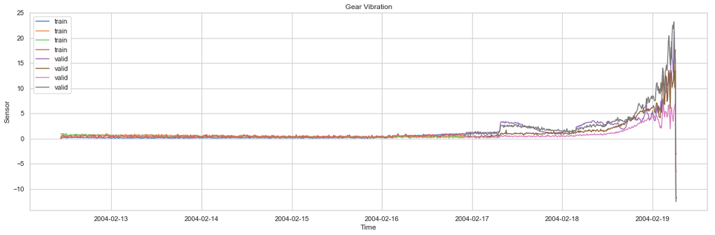

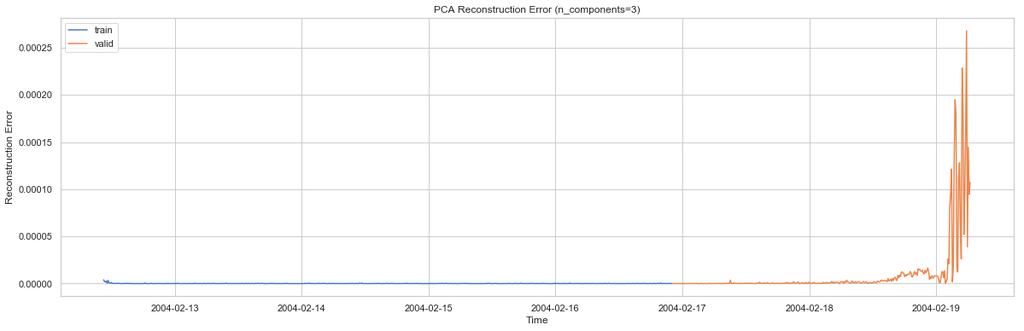

```python
plt.figure(figsize=(20,6))
plt.plot(x_train, label='train')
plt.plot(x_valid, label='valid')
plt.legend()
plt.xlabel('Time')
plt.ylabel('Sensor')
plt.title('Gear Vibration')
plt.show()

plt.figure(figsize=(20, 6))
plt.plot(x_train_mse['Reconstruction Error'], label='train')
plt.plot(x_valid_mse['Reconstruction Error'], label='valid')
plt.legend()
plt.xlabel('Time')
plt.ylabel('Reconstruction Error')
plt.title('PCA Reconstruction Error (n_components=3)')
plt.show()
```

## Conclusion

- The features of normal data were trained by usig normal data only. Anomaly could be dected by using reconstruction error inferenced.
- PCA Reconstruction compressed 4 features as single value.
- PCA Reconstruction error plot showed similar trend with original sensor plot, which means PCA reconstruction error well summarized given data.
- If the labels of defect were given, the model could be evaluated by AUROC which distinguishes normal/abrnomal by using reconstruction error.
- As labels didn't exist, threshold for normal/abnormal couldn't set.
- It's not worthy to set threshold without knowing which samples are defect, hence it's not done.
- **Data will be given in the future will have labels, thus model can be evaluted by AUROC, AUPRC**

# Novelty Detection using VAE Reconsturction Error

```python
device = torch.device('cuda:0' if torch.cuda.is_available() else 'cpu')
batch_size= 16
input_dim = 4
epochs = 3000
lr = 1e-3
```

```python
x_train = df[:'2004-02-16 22:02:39']
x_valid = df['2004-02-16 22:02:39':'2004-02-17 21:12:39']
x_test = df['2004-02-17 21:12:39':]
```

```python
minmaxscaler = MinMaxScaler()

x_train = pd.DataFrame(minmaxscaler.fit_transform(x_train), columns=x_train.columns, index=x_train.index)
x_valid = pd.DataFrame(minmaxscaler.transform(x_valid), columns=x_valid.columns, index=x_valid.index)
x_test = pd.DataFrame(minmaxscaler.transform(x_test), columns=x_test.columns, index=x_test.index)
```

```python
x_train_torch = torch.from_numpy(x_train.values).float()
x_valid_torch = torch.from_numpy(x_valid.values).float()
x_test_torch = torch.from_numpy(x_test.values).float()
```

```python
train_loader = DataLoader(x_train_torch, batch_size=batch_size, shuffle=True)
valid_loader = DataLoader(x_valid_torch, batch_size=batch_size, shuffle=True)
test_loader = DataLoader(x_test_torch, batch_size=batch_size, shuffle=True)
```

## Bottleneck Dimension = 2

```python
z_dim = 2
```

```python
class VAE(nn.Module) :
    def __init__(self) :
        super(VAE,self).__init__()
        self.fc1 = nn.Linear(4, 10)
        self.fc21 = nn.Linear(10, 2)
        self.fc22 = nn.Linear(10, 2)

        self.fc3 = nn.Linear(2, 10)
        self.fc4 = nn.Linear(10, 4)
        self.relu = nn.ReLU()

    def encode(self, x) :
        h1 = self.relu(self.fc1(x))
        return self.fc21(h1), self.fc22(h1)

    def reparameterize(self, mu, log_var) :
        std = torch.exp(log_var/2)
        eps = torch.rand_like(std)
        return mu+eps*std

    def decode(self, z) :
        h2 = self.relu(self.fc3(z))
        return self.fc4(h2)

    def forward(self, x) :
        mu, log_var = self.encode(x)
        z = self.reparameterize(mu, log_var)
        x_recon = self.decode(z)
        return x_recon, mu, log_var
```

```python
model = VAE().to(device)
optimizer = torch.optim.Adam(model.parameters(), lr=lr)
```

```python
train_loss = []
valid_loss = []
best_model = copy.deepcopy(model)
lowest_loss = 10000

outer = tqdm.tqdm(total=epochs, desc='Epoch', position=0)

for epoch in range(epochs) :
    # train
    loss_per_epoch = 0
    model.train()

    for x in train_loader :
        x_recon, mu, log_var = model(x)

        recon_loss = F.mse_loss(x_recon, x, reduction='sum')
        kld = -0.5 * torch.sum(1+log_var-mu.pow(2)-log_var.exp())
        loss = recon_loss + kld
        loss_per_epoch += loss

        optimizer.zero_grad()
        loss.backward()
        optimizer.step()
    train_loss.append(loss_per_epoch / (len(train_loader.dataset)/batch_size) )

    # validation
    loss_per_epoch = 0
    model.eval()
    with torch.no_grad() :
        for x in valid_loader :
            x_recon , mu, log_var = model(x)

            recon_loss = F.mse_loss(x_recon, x, reduction='sum')
            kld = -0.5 * torch.sum(1+log_var-mu.pow(2)-log_var.exp())
            loss = recon_loss + kld
            loss_per_epoch += recon_loss.item() + kld
    current_valid_loss = loss_per_epoch / (len(valid_loader.dataset)/batch_size)
    valid_loss.append(current_valid_loss)

    # save best model
    if epoch == 0 :
        lowest_loss = current_valid_loss
    else :
        if current_valid_loss <= lowest_loss :
            lowest_loss = current_valid_loss
            best_model = copy.deepcopy(model)

    outer.update(1)
```

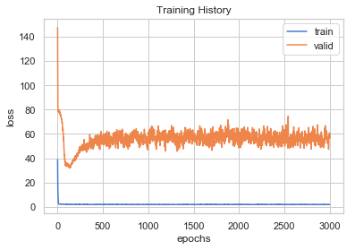

```python
plt.plot(train_loss, label='train')
plt.plot(valid_loss, label='valid')
plt.xlabel('epochs')
plt.ylabel('loss')
plt.legend()
plt.title('Training History')
plt.show()
```

```python
train_recon = best_model(x_train_torch)[0]
valid_recon = best_model(x_valid_torch)[0]
test_recon = best_model(x_test_torch)[0]
```

```python
x_train_vae_recon = pd.DataFrame(train_recon.detach().numpy(), columns=x_train.columns, index=x_train.index)
x_valid_vae_recon = pd.DataFrame(valid_recon.detach().numpy(), columns=x_valid.columns, index=x_valid.index)
x_test_vae_recon = pd.DataFrame(test_recon.detach(). numpy(), columns=x_test.columns, index=x_test.index)
```

[output not shown]

```python
x_train_mse = (x_train_vae_recon - x_train)
x_valid_mse = (x_valid_vae_recon - x_valid)
x_test_mse = (x_test_vae_recon - x_test)
```

```python
x_train_mse['Reconstruction Error'] = x_train_mse.mean(axis=1).apply(lambda x : x*x)
x_valid_mse['Reconstruction Error'] = x_valid_mse.mean(axis=1).apply(lambda x : x*x)
x_test_mse['Reconstruction Error'] = x_test_mse.mean(axis=1).apply(lambda x : x*x)
```

```python
display(x_train.head(),)
display(x_train_vae_recon.head())
display(x_train_mse.head())
```

|  | Bearing 1 | Bearing 2 | Bearing 3 | Bearing 4 |
| --- | --- | --- | --- | --- |
| 2004-02-12 10:32:39 | 0.002152 | 0.000000 | 0.851843 | 0.088117 |
| 2004-02-12 10:42:39 | 0.037843 | 0.364172 | 0.959840 | 0.536515 |
| 2004-02-12 10:52:39 | 0.104727 | 0.401176 | 0.913750 | 0.506727 |
| 2004-02-12 11:02:39 | 0.170414 | 0.337099 | 0.961833 | 0.700840 |
| 2004-02-12 11:12:39 | 0.165312 | 0.632695 | 0.815186 | 0.712082 |

|  | Bearing 1 | Bearing 2 | Bearing 3 | Bearing 4 |
| --- | --- | --- | --- | --- |
| 2004-02-12 10:32:39 | 0.205759 | 0.516963 | 0.421281 | 0.420528 |
| 2004-02-12 10:42:39 | 0.182593 | 0.517504 | 0.425911 | 0.404980 |
| 2004-02-12 10:52:39 | 0.219581 | 0.433184 | 0.337692 | 0.397972 |
| 2004-02-12 11:02:39 | 0.142171 | 0.475738 | 0.388426 | 0.356774 |
| 2004-02-12 11:12:39 | 0.138406 | 0.561779 | 0.480876 | 0.396666 |

|  | Bearing 1 | Bearing 2 | Bearing 3 | Bearing 4 | Reconstruction Error |
| --- | --- | --- | --- | --- | --- |
| 2004-02-12 10:32:39 | 0.203606 | 0.516963 | -0.430561 | 0.332410 | 0.024213 |
| 2004-02-12 10:42:39 | 0.144750 | 0.153331 | -0.533929 | -0.131535 | 0.008436 |
| 2004-02-12 10:52:39 | 0.114854 | 0.032008 | -0.576058 | -0.108755 | 0.018087 |
| 2004-02-12 11:02:39 | -0.028243 | 0.138639 | -0.573407 | -0.344066 | 0.040711 |
| 2004-02-12 11:12:39 | -0.026907 | -0.070915 | -0.334311 | -0.315415 | 0.034927 |

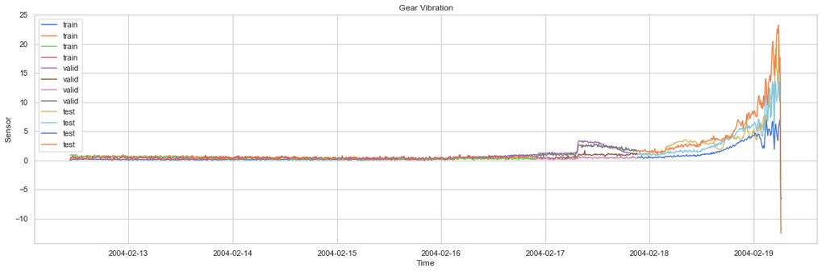

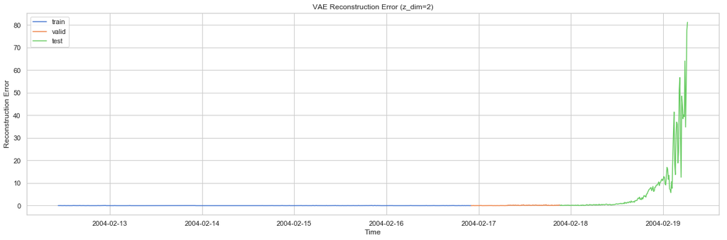

```python
plt.figure(figsize=(20,6))
plt.plot(x_train, label='train')
plt.plot(x_valid, label='valid')
plt.plot(x_test, label='test')
plt.legend()
plt.xlabel('Time')
plt.ylabel('Sensor')
plt.title('Gear Vibration')
plt.show()

plt.figure(figsize=(20, 6))
plt.plot(x_train_mse['Reconstruction Error'], label='train')
plt.plot(x_valid_mse['Reconstruction Error'], label='valid')
plt.plot(x_test_mse['Reconstruction Error'], label='test')
plt.legend()
plt.xlabel('Time')
plt.ylabel('Reconstruction Error')
plt.title('VAE Reconstruction Error (z_dim=2)')
plt.show()
```

## Bottleneck Dimension = 3

```python
z_dim = 3
```

```python
class VAE(nn.Module) :
    def __init__(self) :
        super(VAE,self).__init__()
        self.fc1 = nn.Linear(4, 10)
        self.fc21 = nn.Linear(10, 3)
        self.fc22 = nn.Linear(10, 3)

        self.fc3 = nn.Linear(3, 10)
        self.fc4 = nn.Linear(10, 4)
        self.relu = nn.ReLU()

    def encode(self, x) :
        h1 = self.relu(self.fc1(x))
        return self.fc21(h1), self.fc22(h1)

    def reparameterize(self, mu, log_var) :
        std = torch.exp(log_var/2)
        eps = torch.rand_like(std)
        return mu+eps*std

    def decode(self, z) :
        h2 = self.relu(self.fc3(z))
        return self.fc4(h2)

    def forward(self, x) :
        mu, log_var = self.encode(x)
        z = self.reparameterize(mu, log_var)
        x_recon = self.decode(z)
        return x_recon, mu, log_var
```

```python
model = VAE().to(device)
optimizer = torch.optim.Adam(model.parameters(), lr=lr)
```

```python
train_loss = []
valid_loss = []
best_model = copy.deepcopy(model)
lowest_loss = 10000

outer = tqdm.tqdm(total=epochs, desc='Epoch', position=0)

for epoch in range(epochs) :
    # train
    loss_per_epoch = 0
    model.train()

    for x in train_loader :
        x_recon, mu, log_var = model(x)

        recon_loss = F.mse_loss(x_recon, x, reduction='sum')
        kld = -0.5 * torch.sum(1+log_var-mu.pow(2)-log_var.exp())
        loss = recon_loss + kld
        loss_per_epoch += loss

        optimizer.zero_grad()
        loss.backward()
        optimizer.step()
    train_loss.append(loss_per_epoch / (len(train_loader.dataset)/batch_size) )

    # validation
    loss_per_epoch = 0
    model.eval()
    with torch.no_grad() :
        for x in valid_loader :
            x_recon , mu, log_var = model(x)

            recon_loss = F.mse_loss(x_recon, x, reduction='sum')
            kld = -0.5 * torch.sum(1+log_var-mu.pow(2)-log_var.exp())
            loss = recon_loss + kld
            loss_per_epoch += recon_loss.item() + kld
    current_valid_loss = loss_per_epoch / (len(valid_loader.dataset)/batch_size)
    valid_loss.append(current_valid_loss)

    # save best model
    if epoch == 0 :
        lowest_loss = current_valid_loss
    else :
        if current_valid_loss <= lowest_loss :
            lowest_loss = current_valid_loss
            best_model = copy.deepcopy(model)

    outer.update(1)
```

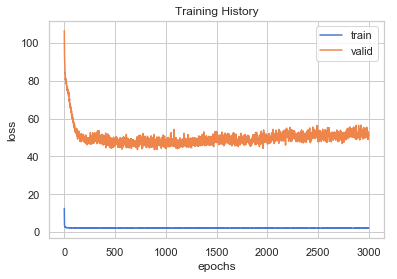

```python
plt.plot(train_loss, label='train')
plt.plot(valid_loss, label='valid')
plt.xlabel('epochs')
plt.ylabel('loss')
plt.legend()
plt.title('Training History')
plt.show()
```

```python
train_recon = best_model(x_train_torch)[0]
valid_recon = best_model(x_valid_torch)[0]
test_recon = best_model(x_test_torch)[0]
```

```python
x_train_vae_recon = pd.DataFrame(train_recon.detach().numpy(), columns=x_train.columns, index=x_train.index)
x_valid_vae_recon = pd.DataFrame(valid_recon.detach().numpy(), columns=x_valid.columns, index=x_valid.index)
x_test_vae_recon = pd.DataFrame(test_recon.detach(). numpy(), columns=x_test.columns, index=x_test.index)
```

[output not shown]

```python
x_train_mse = (x_train_vae_recon - x_train)
x_valid_mse = (x_valid_vae_recon - x_valid)
x_test_mse = (x_test_vae_recon - x_test)
```

```python
x_train_mse['Reconstruction Error'] = x_train_mse.mean(axis=1).apply(lambda x : x*x)
x_valid_mse['Reconstruction Error'] = x_valid_mse.mean(axis=1).apply(lambda x : x*x)
x_test_mse['Reconstruction Error'] = x_test_mse.mean(axis=1).apply(lambda x : x*x)
```

```python
display(x_train.head(),)
display(x_train_vae_recon.head())
display(x_train_mse.head())
```

|  | Bearing 1 | Bearing 2 | Bearing 3 | Bearing 4 |
| --- | --- | --- | --- | --- |
| 2004-02-12 10:32:39 | 0.002152 | 0.000000 | 0.851843 | 0.088117 |
| 2004-02-12 10:42:39 | 0.037843 | 0.364172 | 0.959840 | 0.536515 |
| 2004-02-12 10:52:39 | 0.104727 | 0.401176 | 0.913750 | 0.506727 |
| 2004-02-12 11:02:39 | 0.170414 | 0.337099 | 0.961833 | 0.700840 |
| 2004-02-12 11:12:39 | 0.165312 | 0.632695 | 0.815186 | 0.712082 |

|  | Bearing 1 | Bearing 2 | Bearing 3 | Bearing 4 |
| --- | --- | --- | --- | --- |
| 2004-02-12 10:32:39 | 0.274581 | 0.454213 | 0.344379 | 0.446383 |
| 2004-02-12 10:42:39 | 0.291919 | 0.478838 | 0.369266 | 0.464424 |
| 2004-02-12 10:52:39 | 0.136212 | 0.494747 | 0.406424 | 0.374942 |
| 2004-02-12 11:02:39 | 0.137311 | 0.590052 | 0.526276 | 0.423193 |
| 2004-02-12 11:12:39 | 0.235123 | 0.506643 | 0.400674 | 0.449933 |

|  | Bearing 1 | Bearing 2 | Bearing 3 | Bearing 4 | Reconstruction Error |
| --- | --- | --- | --- | --- | --- |
| 2004-02-12 10:32:39 | 0.272428 | 0.454213 | -0.507464 | 0.358265 | 0.020840 |
| 2004-02-12 10:42:39 | 0.254076 | 0.114666 | -0.590574 | -0.072091 | 0.005399 |
| 2004-02-12 10:52:39 | 0.031484 | 0.093571 | -0.507326 | -0.131785 | 0.016516 |
| 2004-02-12 11:02:39 | -0.033104 | 0.252954 | -0.435556 | -0.277647 | 0.015212 |
| 2004-02-12 11:12:39 | 0.069810 | -0.126052 | -0.414512 | -0.262148 | 0.033572 |

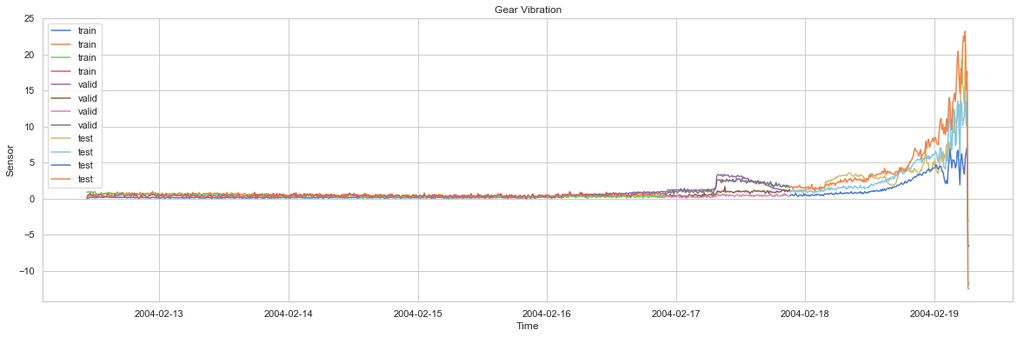

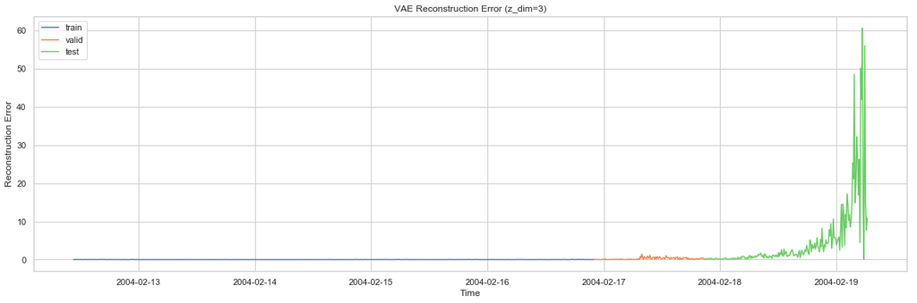

```python
plt.figure(figsize=(20,6))
plt.plot(x_train, label='train')
plt.plot(x_valid, label='valid')
plt.plot(x_test, label='test')
plt.legend()
plt.xlabel('Time')
plt.ylabel('Sensor')
plt.title('Gear Vibration')
plt.show()

plt.figure(figsize=(20, 6))
plt.plot(x_train_mse['Reconstruction Error'], label='train')
plt.plot(x_valid_mse['Reconstruction Error'], label='valid')
plt.plot(x_test_mse['Reconstruction Error'], label='test')
plt.legend()
plt.xlabel('Time')
plt.ylabel('Reconstruction Error')
plt.title('VAE Reconstruction Error (z_dim=3)')
plt.show()
```

## Conclusion

- The features of normal data were trained by usig normal data only. Anomaly could be dected by using reconstruction error inferenced.
- VAE Reconstruction compressed 4 features as single value.
- In order to prevent overfitting, dataset was spllited as train, valid, test dataset. Best model was saved since loss of validation set, which has similiar distribution with training set, started increasing.
- VAE Reconstruction error plot showed similar trend with original sensor plot, which means VAE reconstruction error well summarized given data.
- If the labels of defect were given, the model could be evaluated by AUROC which distinguishes normal/abrnomal by using reconstruction error.
- As labels didn't exist, threshold for normal/abnormal couldn't set.
- It's not worthy to set threshold without knowing which samples are defect, hence it's not done.
- **Data will be given in the future will have labels, thus model can be evaluted by AUROC, AUPRC**